# Final Submission Insights

Singapore fertility decline: four supporting insight plots

Author

Team 11

## Purpose

This file combines the four insight plots selected for the final submission. It is kept separate from the earlier working files so the original exploration QMDs remain untouched.

```r
library(tidyverse)
library(scales)

data_dir <- "datasets"
```

```r
read_singstat_wide <- function(path) {
  lines <- readLines(path, warn = FALSE)

  header_index <- which(
    stringr::str_detect(lines, "^Data\\s*Series\\s*,")
  )[1]

  if (is.na(header_index)) {
    stop("No 'Data Series' header found in: ", path)
  }

  raw <- readr::read_csv(
    path,
    skip = header_index - 1,
    na = c("", "na", "NA", "N.A.", "-"),
    show_col_types = FALSE
  )

  raw <- dplyr::rename_with(raw, trimws)
  names(raw)[1] <- "data_series"

  raw |>
    dplyr::mutate(data_series = stringr::str_squish(data_series)) |>
    dplyr::filter(!is.na(data_series), data_series != "")
}

to_long_years <- function(data) {
  data |>
    dplyr::mutate(dplyr::across(dplyr::matches("^\\d{4}$"), as.character)) |>
    tidyr::pivot_longer(
      cols = dplyr::matches("^\\d{4}$"),
      names_to = "year",
      values_to = "value"
    ) |>
    dplyr::mutate(
      year = as.integer(year),
      value = readr::parse_number(as.character(value))
    ) |>
    dplyr::filter(!is.na(year))
}
```

## Main visualisation: Singapore fertility, female LFPR and policy context

This is the main visual that the supporting insights are meant to explain. It shows the long-term fertility decline, the age groups contributing to births, female LFPR by age group, major recessions and key birth-policy milestones in one view.

```r
fertility_main_wide <- read_singstat_wide(file.path(data_dir, "BirthsAndFertilityRatesAnnual.csv"))
lfpr_main_wide <- read_singstat_wide(file.path(data_dir, "M182201.csv"))

standardise_age_group <- function(x) {
  x |>
    stringr::str_squish() |>
    stringr::str_replace_all("\\s*-\\s*", "-")
}

main_age_groups <- c(
  "15-19 Years",
  "20-24 Years",
  "25-29 Years",
  "30-34 Years",
  "35-39 Years",
  "40-44 Years",
  "45-49 Years"
)

asfr_by_age_main <- fertility_main_wide |>
  mutate(age_group = standardise_age_group(data_series)) |>
  filter(age_group %in% main_age_groups) |>
  to_long_years() |>
  transmute(
    year,
    age_group = factor(age_group, levels = main_age_groups),
    asfr = value
  ) |>
  filter(year >= 1980, !is.na(asfr)) |>
  arrange(age_group, year)

lfpr_female_main <- lfpr_main_wide |>
  mutate(
    section = case_when(
      data_series == "Female Resident Participation Rate" ~ "Female",
      data_series %in% c(
        "Total Resident Participation Rate",
        "Male Resident Participation Rate"
      ) ~ "Other",
      TRUE ~ NA_character_
    )
  ) |>
  tidyr::fill(section, .direction = "down") |>
  filter(
    section == "Female",
    data_series != "Female Resident Participation Rate"
  ) |>
  mutate(age_group = standardise_age_group(data_series)) |>
  filter(age_group %in% main_age_groups) |>
  to_long_years() |>
  transmute(
    year,
    age_group = factor(age_group, levels = main_age_groups),
    female_lfpr_pct = value
  ) |>
  filter(year >= 1990, !is.na(female_lfpr_pct)) |>
  arrange(age_group, year)

recession_events_main <- tibble(
  recession = c(
    "1985 recession",
    "Asian Financial Crisis",
    "Global Financial Crisis",
    "COVID-19 recession"
  ),
  year = c(1985, 1998, 2009, 2020)
) |>
  mutate(
    xmin = year - 0.55,
    xmax = year + 0.55
  )

birth_policy_events_main <- tibble(
  year = c(1984, 1987, 2001, 2004, 2008, 2013),
  policy = c(
    "Graduate Mothers Scheme",
    "Have Three or More policy",
    "Baby Bonus",
    "M&P Package",
    "Enhanced M&P Package",
    "Enhanced M&P Package"
  ),
  label_level = c(1, 2, 1, 2, 1, 2)
)

main_age_group_colours <- c(
  "15-19 Years" = "#D73027",
  "20-24 Years" = "#FC8D59",
  "25-29 Years" = "#FEE08B",
  "30-34 Years" = "#91CF60",
  "35-39 Years" = "#1A9850",
  "40-44 Years" = "#4575B4",
  "45-49 Years" = "#7B3294"
)

asfr_total_by_year_main <- asfr_by_age_main |>
  group_by(year) |>
  summarise(total_asfr = sum(asfr, na.rm = TRUE), .groups = "drop")

asfr_max_main <- max(asfr_total_by_year_main$total_asfr, na.rm = TRUE)
lfpr_scale_main <- asfr_max_main / 100

lfpr_line_main <- lfpr_female_main |>
  mutate(age_group = factor(age_group, levels = main_age_groups)) |>
  filter(
    year >= min(asfr_by_age_main$year),
    year <= max(asfr_by_age_main$year)
  )
```

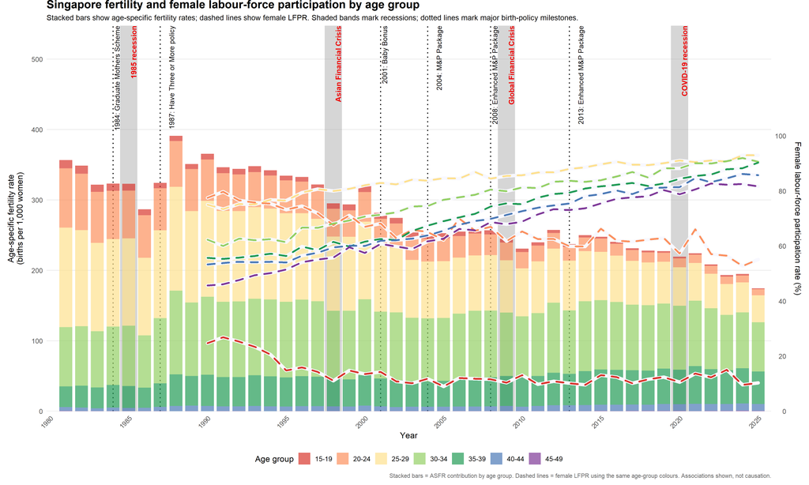

```r
ggplot() +
  geom_rect(
    data = recession_events_main,
    aes(xmin = xmin, xmax = xmax, ymin = -Inf, ymax = Inf),
    inherit.aes = FALSE,
    fill = "grey60",
    alpha = 0.4
  ) +
  geom_text(
    data = recession_events_main,
    aes(x = year, y = Inf, label = recession),
    inherit.aes = FALSE,
    angle = 90,
    vjust = 1.35,
    hjust = 1,
    size = 3.5,
    fontface = "bold",
    colour = "red2"
  ) +
  geom_vline(
    data = birth_policy_events_main,
    aes(xintercept = year),
    inherit.aes = FALSE,
    linetype = "dotted",
    linewidth = 0.75,
    colour = "black"
  ) +
  geom_text(
    data = birth_policy_events_main,
    aes(
      x = year,
      y = Inf,
      label = paste0(year, ": ", policy),
      vjust = if_else(label_level == 1, 1.25, 2.65)
    ),
    inherit.aes = FALSE,
    angle = 90,
    hjust = 1,
    size = 3.3,
    colour = "black"
  ) +
  geom_col(
    data = asfr_by_age_main,
    aes(x = year, y = asfr, fill = age_group),
    width = 0.82,
    alpha = 0.68
  ) +
  geom_line(
    data = lfpr_line_main,
    aes(x = year, y = female_lfpr_pct * lfpr_scale_main, group = age_group),
    colour = "ghostwhite",
    linewidth = 2.2,
    lineend = "round"
  ) +
  geom_line(
    data = lfpr_line_main,
    aes(
      x = year,
      y = female_lfpr_pct * lfpr_scale_main,
      colour = age_group,
      group = age_group
    ),
    linewidth = 1.2,
    linetype = "dashed",
    alpha = 0.98,
    lineend = "round"
  ) +
  scale_x_continuous(
    limits = c(1980, 2025.6),
    breaks = seq(1980, 2025, 5),
    expand = expansion(mult = c(0.005, 0.005))
  ) +
  scale_y_continuous(
    name = "Age-specific fertility rate\n(births per 1,000 women)",
    sec.axis = sec_axis(
      ~ . / lfpr_scale_main,
      name = "Female labour-force participation rate (%)",
      breaks = seq(0, 100, 20)
    ),
    expand = expansion(mult = c(0, 0.40))
  ) +
  scale_fill_manual(
    values = main_age_group_colours,
    name = "Age group",
    labels = function(x) str_remove(x, " Years")
  ) +
  scale_colour_manual(
    values = main_age_group_colours,
    name = "Age group",
    labels = function(x) str_remove(x, " Years")
  ) +
  guides(
    fill = guide_legend(title = "Age group", order = 1, nrow = 1),
    colour = "none"
  ) +
  labs(
    title = "Singapore fertility and female labour-force participation by age group",
    subtitle = paste0(
      "Stacked bars show age-specific fertility rates; dashed lines show female LFPR. ",
      "Shaded bands mark recessions; dotted lines mark major birth-policy milestones."
    ),
    x = "Year",
    caption = "Stacked bars = ASFR contribution by age group. Dashed lines = female LFPR using the same age-group colours. Associations shown, not causation."
  ) +
  theme_minimal(base_size = 11) +
  theme(
    panel.grid.minor = element_blank(),
    panel.grid.major.x = element_blank(),
    axis.text.x = element_text(angle = 45, hjust = 1),
    axis.title.y.left = element_text(margin = margin(r = 10)),
    axis.title.y.right = element_text(margin = margin(l = 10)),
    plot.title = element_text(face = "bold", size = 15),
    plot.subtitle = element_text(size = 10),
    plot.caption = element_text(size = 8, colour = "grey40"),
    legend.position = "bottom",
    legend.box = "horizontal",
    plot.margin = margin(0, 10, 8, 10)
  )
```

## Insight 1: Female university attainment, LFPR and first-birth timing

**Question:** Did female university attainment rise alongside higher female labour-force participation and later first birth?

**Datasets used:**

| Dataset | File | Source | Range |
| --- | --- | --- | --- |
| Female university-qualified residents 25+ | `M850581_female_university_qualified.csv` | SingStat M850581 | 1990 to 2025 |
| Female LFPR, aggregate 15+ | `M182201_female_lfpr_aggregate.csv` | SingStat M182201 | 1990 to 2025 |
| Median age of resident mothers at first birth | `M810741_median_age_first_birth.csv` | SingStat M810741 | 1990 to 2025 |

**Reading the plot:** The line shows growth in female university-qualified residents. Larger points mean higher female LFPR. Point colour shows the median age at first birth.

```r
grads <- readr::read_csv(file.path(data_dir, "M850581_female_university_qualified.csv"))
lfpr <- readr::read_csv(file.path(data_dir, "M182201_female_lfpr_aggregate.csv"))
birthage <- readr::read_csv(file.path(data_dir, "M810741_median_age_first_birth.csv"))

insight1_data <- grads |>
  left_join(lfpr, by = "year") |>
  left_join(birthage, by = "year")
```

```r
age_band_stops <- tibble(
  midpoint = c(17, 22, 27, 32, 37, 42, 47),
  colour = c("#D73027", "#FC8D59", "#FEE08B", "#A6D96A", "#1A9850", "#4575B4", "#762A83")
)

age_colour_ramp <- colorRamp(age_band_stops$colour, space = "Lab")

birth_age_to_colour <- function(age) {
  t <- approx(
    age_band_stops$midpoint,
    seq(0, 1, length.out = nrow(age_band_stops)),
    xout = age,
    rule = 2
  )$y
  cols <- age_colour_ramp(t)
  rgb(cols[, 1], cols[, 2], cols[, 3], maxColorValue = 255)
}

insight1_data <- insight1_data |>
  mutate(point_colour = birth_age_to_colour(median_age_first_birth))

insight1_legend_ages <- c(28, 29, 30, 31, 32)
insight1_legend_colours <- birth_age_to_colour(insight1_legend_ages)
```

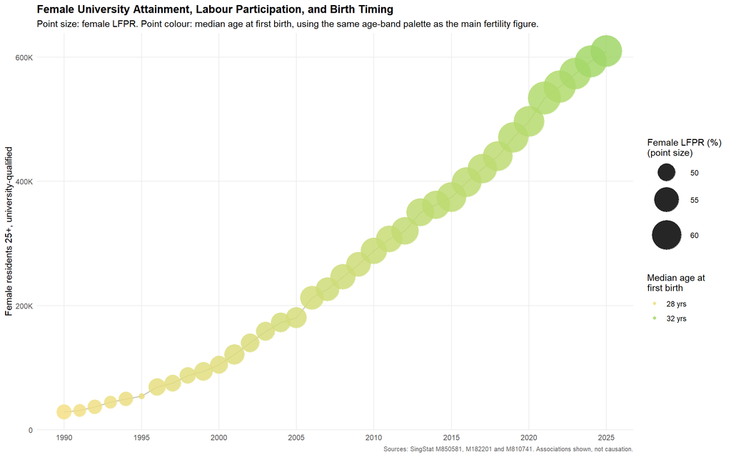

```r
ggplot(insight1_data, aes(x = year, y = female_university_qualified)) +
  geom_line(colour = "#c3c2b7", linewidth = 0.6) +
  geom_point(aes(size = female_lfpr_pct, colour = point_colour), alpha = 0.85) +
  scale_size(name = "Female LFPR (%)\n(point size)", range = c(3, 18)) +
  scale_colour_identity(
    name = "Median age at\nfirst birth",
    breaks = insight1_legend_colours,
    labels = paste0(insight1_legend_ages, " yrs"),
    guide = "legend"
  ) +
  scale_x_continuous(breaks = scales::breaks_pretty(n = 8)) +
  scale_y_continuous(
    name = "Female residents 25+, university-qualified",
    labels = scales::label_number(scale_cut = scales::cut_short_scale())
  ) +
  labs(
    title = "Female University Attainment, Labour Participation, and Birth Timing",
    subtitle = "Point size: female LFPR. Point colour: median age at first birth, using the same age-band palette as the main fertility figure.",
    x = NULL,
    caption = "Sources: SingStat M850581, M182201 and M810741. Associations shown, not causation."
  ) +
  theme_minimal(base_size = 11) +
  theme(
    panel.grid.minor = element_blank(),
    plot.title = element_text(face = "bold", size = 13),
    plot.caption = element_text(size = 7.5, colour = "grey40"),
    legend.position = "right"
  )
```

## Insight 2: Literacy, schooling duration and youth labour withdrawal

**Question:** Did young adulthood shift toward longer schooling while younger female LFPR fell?

**Datasets used:**

| Dataset | File | Source | Range |
| --- | --- | --- | --- |
| Female literacy rate, 15+ | `M850001_female_literacy_rate.csv` | SingStat M850001 | used from 1960 |
| Female mean years of schooling, 25+ | `M850591_female_mean_years_schooling.csv` | SingStat M850591 | 1980 to 2024 |
| Female LFPR by age, 15 to 19 and 20 to 24 | `M182201_female_lfpr_by_age_15_24.csv` | SingStat M182201 | 1990 to 2025 |

**Reading the plot:** The purple background shows female literacy from 1960. The brown bars and younger female LFPR lines start later where those datasets are available, so the pre-1980 blank areas are honest data gaps.

```r
literacy <- readr::read_csv(file.path(data_dir, "M850001_female_literacy_rate.csv"))
schooling <- readr::read_csv(file.path(data_dir, "M850591_female_mean_years_schooling.csv"))
lfpr_age <- readr::read_csv(file.path(data_dir, "M182201_female_lfpr_by_age_15_24.csv")) |>
  mutate(age_group = factor(age_group, levels = c("15-19", "20-24")))

schooling_5yr <- schooling |>
  filter(year %in% c(1980, 1985, 1990, 1995, 2000, 2005, 2010, 2015, 2020, 2024))

policy_markers <- tribble(
  ~year, ~label,
  1961, "1961: free universal\nprimary education",
  1994, "1994: curriculum unified\nfor both sexes"
)
```

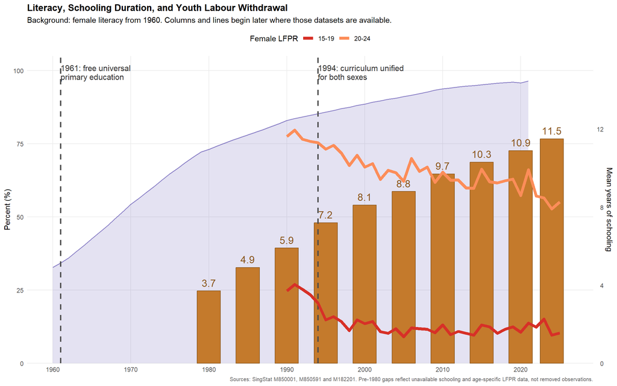

```r
yr_scale <- 100 / 15

ggplot() +
  geom_area(
    data = literacy,
    aes(x = year, y = female_literacy_pct),
    fill = "#4a3aa7",
    alpha = 0.15
  ) +
  geom_line(
    data = literacy,
    aes(x = year, y = female_literacy_pct),
    colour = "#4a3aa7",
    linewidth = 0.7,
    alpha = 0.6
  ) +
  geom_col(
    data = schooling_5yr,
    aes(x = year, y = mean_years_schooling * yr_scale),
    fill = "#c47a2c",
    colour = "#8a561c",
    width = 3
  ) +
  geom_text(
    data = schooling_5yr,
    aes(x = year, y = mean_years_schooling * yr_scale, label = mean_years_schooling),
    vjust = -0.6,
    size = 5,
    colour = "#8a561c"
  ) +
  geom_vline(
    data = policy_markers,
    aes(xintercept = year),
    linetype = "dashed",
    colour = "grey30",
    linewidth = 1
  ) +
  geom_text(
    data = policy_markers,
    aes(x = year, y = 102, label = label),
    hjust = 0,
    vjust = 1,
    size = 4,
    colour = "grey20",
    lineheight = 0.9
  ) +
  geom_line(
    data = lfpr_age,
    aes(x = year, y = lfpr_pct, colour = age_group),
    linewidth = 2,
    na.rm = TRUE
  ) +
  scale_colour_manual(
    name = "Female LFPR",
    values = c("15-19" = "#D73027", "20-24" = "#FC8D59")
  ) +
  scale_x_continuous(breaks = seq(1960, 2025, 10), limits = c(1960, 2026)) +
  scale_y_continuous(
    name = "Percent (%)",
    sec.axis = sec_axis(~ . / yr_scale, name = "Mean years of schooling"),
    limits = c(0, 105),
    expand = c(0, 0)
  ) +
  labs(
    title = "Literacy, Schooling Duration, and Youth Labour Withdrawal",
    subtitle = "Background: female literacy from 1960. Columns and lines begin later where those datasets are available.",
    x = NULL,
    caption = "Sources: SingStat M850001, M850591 and M182201. Pre-1980 gaps reflect unavailable schooling and age-specific LFPR data, not removed observations."
  ) +
  theme_minimal(base_size = 11) +
  theme(
    panel.grid.minor = element_blank(),
    plot.title = element_text(face = "bold", size = 13),
    plot.caption = element_text(size = 7.5, colour = "grey40"),
    legend.position = "top"
  )
```

## Insight 3: Smaller completed families and cost context

**Question:** Did completed family size shift smaller while cost conditions rose?

**Datasets used:**

| Dataset | File | Source | Range |
| --- | --- | --- | --- |
| Ever-married resident females aged 40 to 49 by children born | `ResidentEverMarriedFemalesByAgeGroupAndNumberOfChildrenBornAnnual.csv` | SingStat | 1980 to 2025 |
| Consumer price index, all items | `ConsumerPriceIndexCPI2024AsBaseYearMonthly.csv` | SingStat | 1961 to 2026 |

```r
family_size_wide <- read_singstat_wide(file.path(data_dir, "ResidentEverMarriedFemalesByAgeGroupAndNumberOfChildrenBornAnnual.csv"))
cpi_wide <- readr::read_csv(
  file.path(data_dir, "ConsumerPriceIndexCPI2024AsBaseYearMonthly.csv"),
  na = c("", "na", "NA", "N.A.", "-"),
  show_col_types = FALSE
) |>
  rename(data_series = DataSeries)

cpi_annual <- cpi_wide |>
  filter(data_series == "All Items") |>
  pivot_longer(
    cols = matches("^\\d{4}[A-Za-z]{3}$"),
    names_to = "period",
    values_to = "cpi_index"
  ) |>
  mutate(
    year = as.integer(str_sub(period, 1, 4)),
    cpi_index = readr::parse_number(as.character(cpi_index))
  ) |>
  filter(year >= 1990, year <= 2025) |>
  group_by(year) |>
  summarise(cpi_index = mean(cpi_index, na.rm = TRUE), .groups = "drop")

family_size_tagged <- family_size_wide |>
  mutate(
    age_group = if_else(str_detect(data_series, "^\\d+\\s*-\\s*\\d+\\s+Years$"), data_series, NA_character_),
    children_born = case_when(
      data_series == "None" ~ "None",
      data_series == "1 Child" ~ "1 child",
      data_series == "2 Children" ~ "2 children",
      data_series %in% c("3 Children", "4 Or More Children", "3 Or More Children") ~ "3 or more children",
      TRUE ~ NA_character_
    )
  ) |>
  tidyr::fill(age_group, .direction = "down")

family_size_40_49 <- family_size_tagged |>
  filter(str_detect(age_group, "^40\\s*-\\s*49"), !is.na(children_born)) |>
  to_long_years() |>
  transmute(year, children_born, females = value) |>
  group_by(year) |>
  mutate(
    total_females = sum(females, na.rm = TRUE),
    share_pct = females / total_females * 100
  ) |>
  ungroup()

family_size_selected <- family_size_40_49 |>
  filter(year %in% c(1990, 2000, 2010, 2020, 2025)) |>
  group_by(year, children_born) |>
  summarise(share_pct = sum(share_pct, na.rm = TRUE), .groups = "drop") |>
  mutate(
    children_born = factor(
      children_born,
      levels = c("3 or more children", "2 children", "1 child", "None")
    ),
    label = if_else(share_pct >= 7, paste0(round(share_pct, 0), "%"), "")
  )

cpi_selected <- cpi_annual |>
  filter(year %in% c(1990, 2000, 2010, 2020, 2025)) |>
  arrange(year) |>
  mutate(
    cost_step_pct = (cpi_index / lag(cpi_index) - 1) * 100,
    cost_fill_pct = replace_na(cost_step_pct, 0),
    cost_label = if_else(
      year == 1990,
      "Cost baseline",
      paste0("+", round(cost_step_pct), "% cost")
    )
  )
```

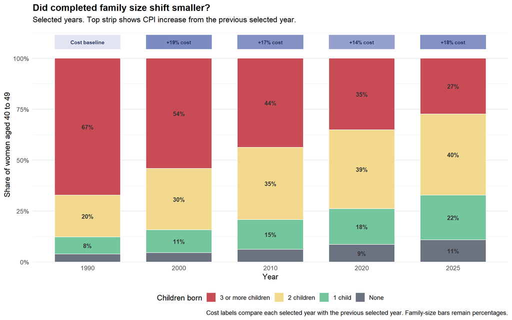

```r
ggplot(family_size_selected, aes(x = factor(year), y = share_pct, fill = children_born)) +
  geom_col(width = 0.72, colour = "white", linewidth = 0.5) +
  geom_text(
    aes(label = label),
    position = position_stack(vjust = 0.5),
    size = 3.6,
    fontface = "bold",
    colour = "grey20"
  ) +
  geom_tile(
    data = cpi_selected,
    aes(x = factor(year), y = 108, alpha = cost_fill_pct),
    inherit.aes = FALSE,
    fill = "#4B5FA8",
    width = 0.72,
    height = 7
  ) +
  geom_text(
    data = cpi_selected,
    aes(
      x = factor(year),
      y = 108,
      label = cost_label
    ),
    inherit.aes = FALSE,
    size = 3,
    fontface = "bold",
    colour = "#24305E"
  ) +
  scale_y_continuous(
    labels = scales::label_percent(scale = 1),
    breaks = seq(0, 100, 25),
    limits = c(0, 114),
    expand = expansion(mult = c(0, 0.01))
  ) +
  scale_fill_manual(
    values = c(
      "3 or more children" = "#C94B55",
      "2 children" = "#F2D98D",
      "1 child" = "#74C69D",
      "None" = "#6B7280"
    )
  ) +
  scale_alpha_continuous(range = c(0.16, 0.72), guide = "none") +
  labs(
    title = "Did completed family size shift smaller?",
    subtitle = "Selected years. Top strip shows CPI increase from the previous selected year.",
    x = "Year",
    y = "Share of women aged 40 to 49",
    fill = "Children born",
    caption = "Cost labels compare each selected year with the previous selected year. Family-size bars remain percentages."
  ) +
  theme_minimal(base_size = 13) +
  theme(
    legend.position = "bottom",
    legend.box = "vertical",
    panel.grid.major.x = element_blank(),
    plot.title = element_text(face = "bold")
  )
```

## Insight 4: Recessions and policies as timing context

**Question:** Did recessions and fertility policies explain sustained fertility changes?

**Dataset used:**

| Dataset | File | Source | Range |
| --- | --- | --- | --- |
| Total fertility rate | `BirthsAndFertilityRatesAnnual.csv` | SingStat | main view uses 1980 to 2025 |
| Policy and recession markers | manual annotation table in this QMD | Team research | selected events |

**Reading the plot:** The dashed line marks each policy year. Shaded bands show recession recovery windows within each policy panel. These markers give context only and should not be read as causal proof.

```r
fertility_wide <- read_singstat_wide(file.path(data_dir, "BirthsAndFertilityRatesAnnual.csv"))

tfr_annual <- fertility_wide |>
  filter(data_series == "Total Fertility Rate (TFR)") |>
  to_long_years() |>
  transmute(year, tfr = value)

policy_events <- tribble(
  ~event_year, ~event_label, ~policy_stance,
  1972, "Stop at Two", "Anti-natalist",
  1987, "Have Three or More", "Pro-natalist",
  2001, "Baby Bonus", "Pro-natalist",
  2013, "Marriage and Parenthood package", "Pro-natalist"
)

economic_shocks <- tribble(
  ~shock_year, ~shock_label, ~severity, ~quarters_below_peak,
  1985, "1985", "Severe", 6,
  1998, "1998", "Severe", 6,
  2001, "2001", "Moderate", 5,
  2009, "2009", "Most severe", 6,
  2020, "2020", "Most severe", 4
)

policy_window <- policy_events |>
  crossing(relative_year = -5:10) |>
  mutate(year = event_year + relative_year) |>
  left_join(tfr_annual, by = "year") |>
  mutate(
    event_label = factor(
      event_label,
      levels = c("Stop at Two", "Have Three or More", "Baby Bonus", "Marriage and Parenthood package")
    )
  )

shock_window <- policy_events |>
  crossing(economic_shocks) |>
  mutate(
    relative_year = shock_year - event_year,
    recovery_years = quarters_below_peak / 4,
    relative_recovery_end = relative_year + recovery_years,
    event_label = factor(
      event_label,
      levels = c("Stop at Two", "Have Three or More", "Baby Bonus", "Marriage and Parenthood package")
    )
  ) |>
  filter(relative_year <= 10, relative_recovery_end >= -5) |>
  mutate(
    xmin = pmax(relative_year, -5),
    xmax = pmin(relative_recovery_end, 10)
  )
```

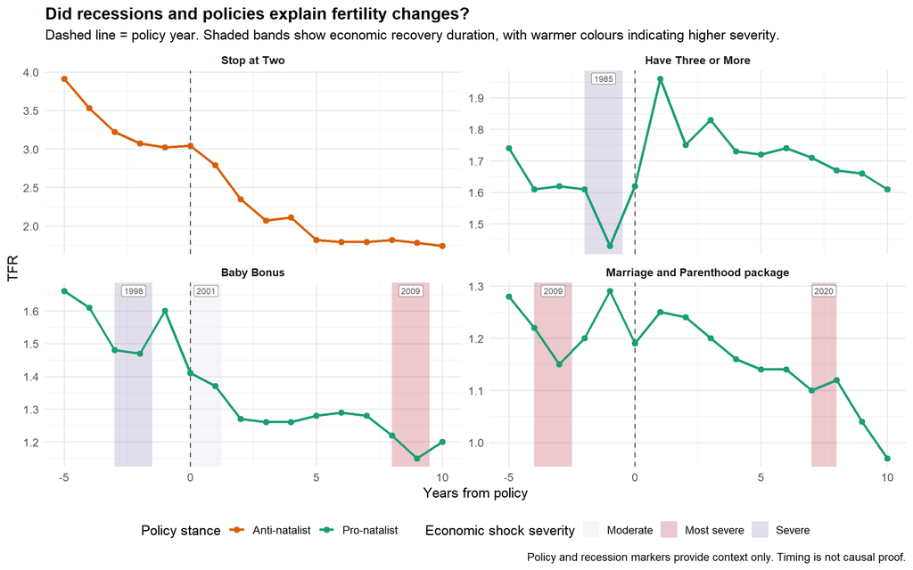

```r
ggplot(policy_window, aes(x = relative_year, y = tfr, colour = policy_stance)) +
  geom_rect(
    data = shock_window,
    aes(xmin = xmin, xmax = xmax, ymin = -Inf, ymax = Inf, fill = severity),
    inherit.aes = FALSE,
    alpha = 0.24
  ) +
  geom_vline(xintercept = 0, linetype = "dashed", colour = "grey35") +
  geom_line(linewidth = 1.1) +
  geom_point(size = 2.3) +
  geom_label(
    data = shock_window,
    aes(x = (xmin + xmax) / 2, y = Inf, label = shock_label),
    inherit.aes = FALSE,
    vjust = 1.2,
    size = 2.8,
    label.size = 0.15,
    fill = "white",
    colour = "grey35"
  ) +
  facet_wrap(~ event_label, scales = "free_y", ncol = 2) +
  scale_colour_manual(values = c("Anti-natalist" = "#D95F02", "Pro-natalist" = "#1B9E77")) +
  scale_fill_manual(
    values = c(
      "Most severe" = "#B2182B",
      "Severe" = "#8073AC",
      "Moderate" = "#D8DAEB"
    )
  ) +
  scale_x_continuous(breaks = c(-5, 0, 5, 10)) +
  labs(
    title = "Did recessions and policies explain fertility changes?",
    subtitle = "Dashed line = policy year. Shaded bands show economic recovery duration, with warmer colours indicating higher severity.",
    x = "Years from policy",
    y = "TFR",
    colour = "Policy stance",
    fill = "Economic shock severity",
    caption = "Policy and recession markers provide context only. Timing is not causal proof."
  ) +
  theme_minimal(base_size = 13) +
  theme(
    legend.position = "bottom",
    plot.title = element_text(face = "bold"),
    strip.text = element_text(face = "bold")
  )
```